# datavis_ggplot2

### Geometry lagen

Bovenop dit basis-canvas kunnen we dan vormen gaan toevoegen. Hier gaan we starten met punten, met de functie geom_point

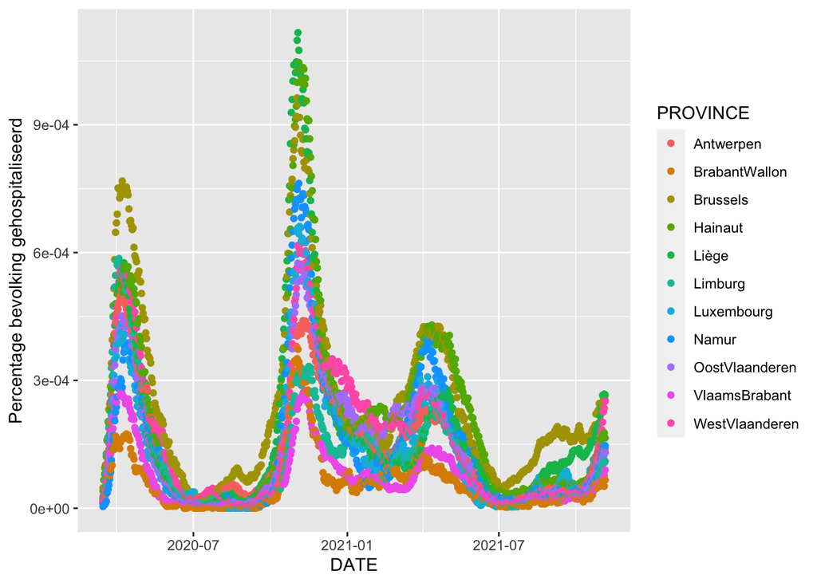

```r
ggplot(data=covid, mapping = aes(x=DATE, y=`Percentage bevolking gehospitaliseerd`, fill=PROVINCE, color=PROVINCE)) +
  geom_point()
```

Aangezien de data een tijds-serie vormt, is het vaak leesbaarder om de punten te verbinden met een lijn met geom_line.

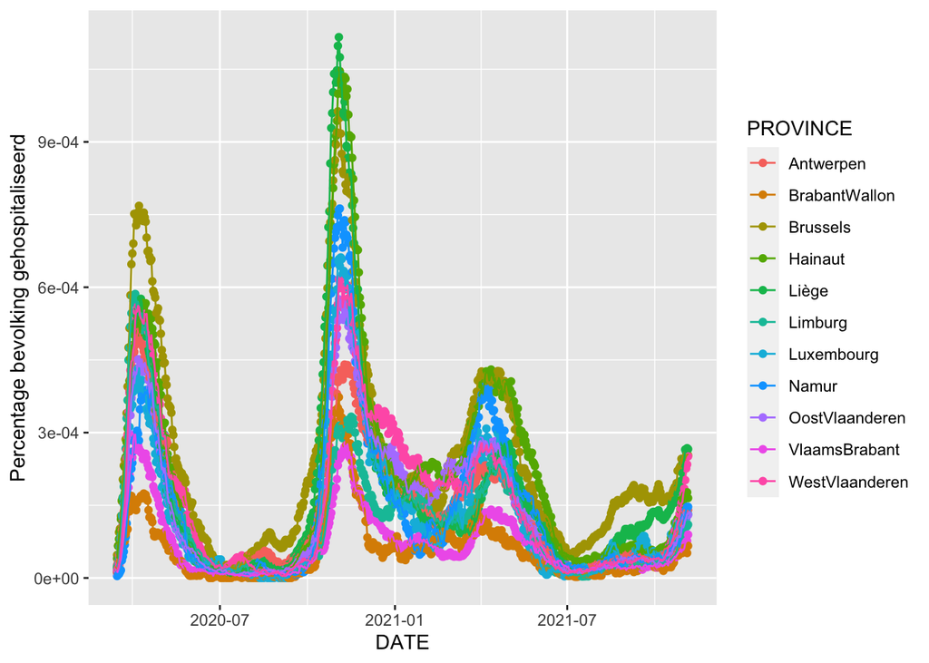

```r
ggplot(data=covid, mapping = aes(x=DATE, y=`Percentage bevolking gehospitaliseerd`, fill=PROVINCE, color=PROVINCE)) +
  geom_point() +
  geom_line()
```

### Wrapping

Op deze manier bekomen we een basis-grafiek. Maar, we hebben eigenlijk te veel informatie om op één scherm te tonen. Om de grafiek leesbaarder te maken, kunnen we hem opsplitsen per provincie. Dit kan je doen me de functie facet_wrap

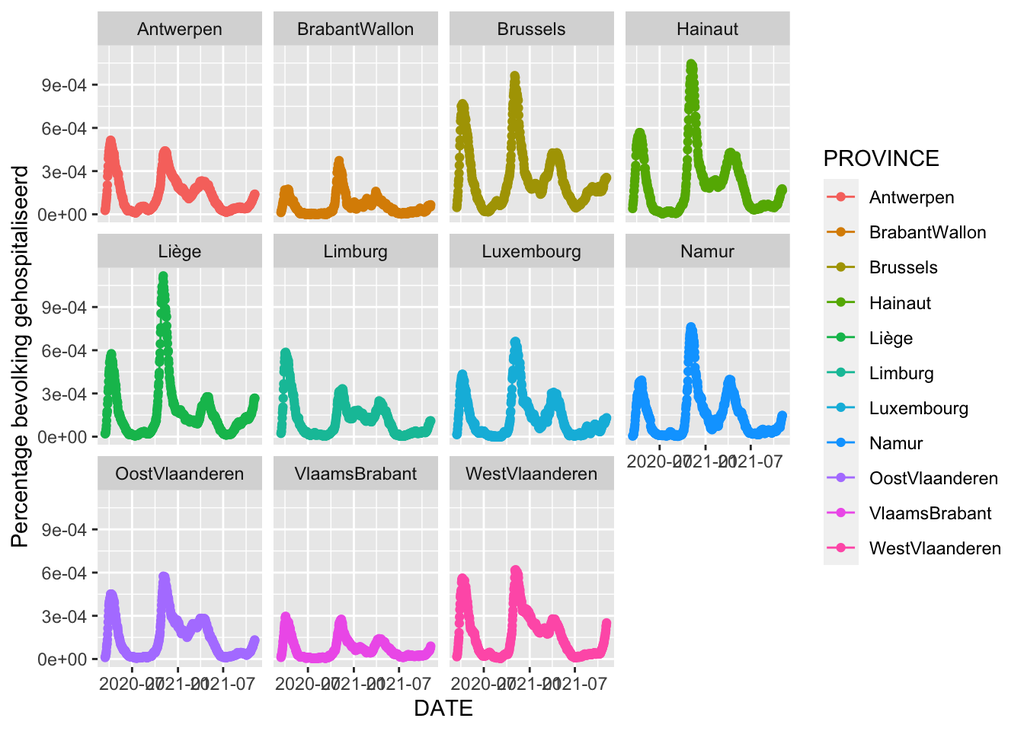

```r
ggplot(data=covid, mapping = aes(x=DATE, y=`Percentage bevolking gehospitaliseerd`, fill=PROVINCE, color=PROVINCE)) +
  geom_point() +
  geom_line() +
  facet_wrap(~PROVINCE)
```

### Theming (1)

Deze grafiek is al heel wat leesbaarder, maar ik hou persoonlijk niet zo van de grijze achtergrond. Daarom kunnen we een ander ggplot thema gebruiken. Een ggplot thema is een verzameling van instellingen die het algemene uitzicht van je plots veranderen. Hier kies ik voor een minimalistisch thema met zo weinig mogelijk rasterlijnen en donkere vlakken.

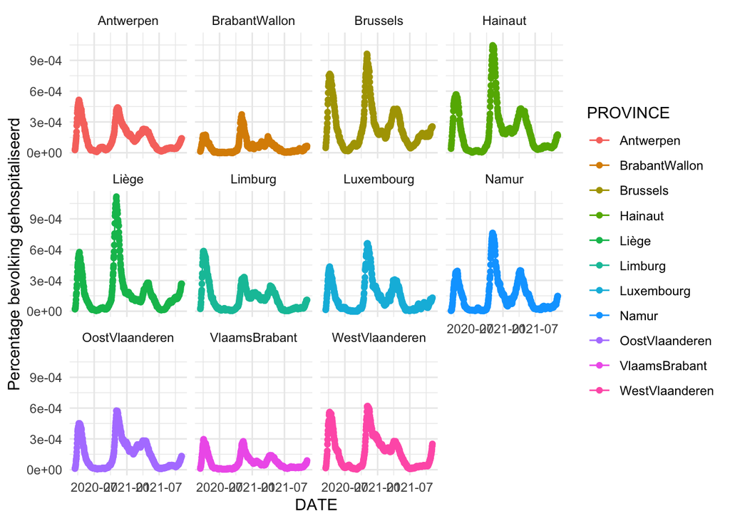

```r
ggplot(data=covid, mapping = aes(x=DATE, y=`Percentage bevolking gehospitaliseerd`, fill=PROVINCE, color=PROVINCE)) +
  geom_point() +
  geom_line() +
  facet_wrap(~PROVINCE) +
  theme_minimal()
```

### Theming (2)

Dit ziet er al minder beladen uit, maar eigenlijk draagt de legende hier niet erg veel bij. Met een extra theme() commando kunnen we de legende verbergen. Door legend dot position op “none” te zetten verbergen we de legend.

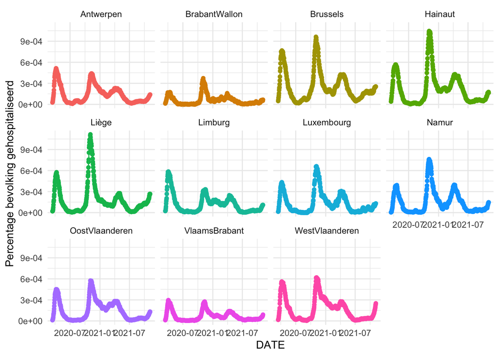

```r
ggplot(data=covid, mapping = aes(x=DATE, y=`Percentage bevolking gehospitaliseerd`, fill=PROVINCE, color=PROVINCE)) +
  geom_point() +
  geom_line() +
  facet_wrap(~PROVINCE) +
  theme_minimal() +
  theme(legend.position="none")
```

### Theming (3)

Met hetzelfde theme commando kunnen we er ook voor zorgen dat de datum-labels op de x-as in een hoek van 45 graden komen te staan zodat ze elkaar niet overlappen. Dit doen we door axis dot text dot x gelijk te zetten aan element_text, met een hoek van 45 graden en een horizontale afstand van 1.

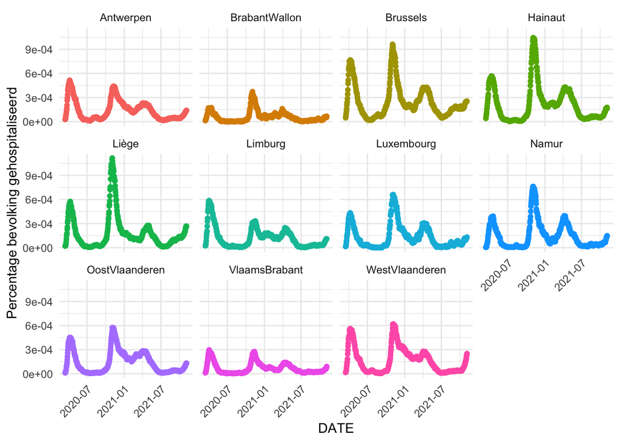

```r
ggplot(data=covid, mapping = aes(x=DATE, y=`Percentage bevolking gehospitaliseerd`, fill=PROVINCE, color=PROVINCE)) +
  geom_point() +
  geom_line() +
  facet_wrap(~PROVINCE) +
  theme_minimal() +
  theme(legend.position="none",
        axis.text.x = element_text(angle = 45, hjust = 1)
        )
```

### Y-as als percentage formatteren

We zijn er bijna, maar de y-as heeft nog steeds een weinig informatieve schaal. Door scale_y_continous toe te voegen en de labels te laten aanmaken door `percent` uit het scales pakket kunnen we dit corrigeren.

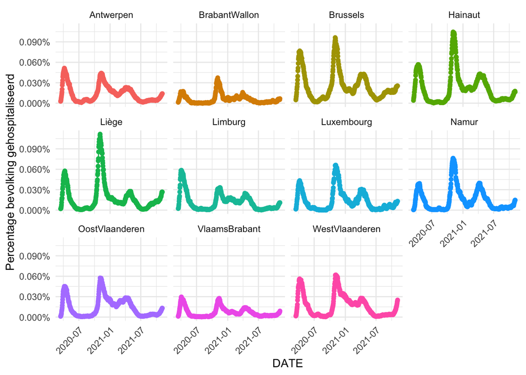

```r
ggplot(data=covid, mapping = aes(x=DATE, y=`Percentage bevolking gehospitaliseerd`, fill=PROVINCE, color=PROVINCE)) +
  geom_point() +
  geom_line() +
  scale_y_continuous(labels=percent) +
  facet_wrap(~PROVINCE) +
  theme_minimal() +
  theme(legend.position="none",
        axis.text.x = element_text(angle = 45, hjust = 1)
        )
```

### Titels

Het enige wat ons nu nog rest is de grafiek een titel geven en de x-as een andere naam geven. Dit kunnen we doen door labs toe te voegen aan onze code.

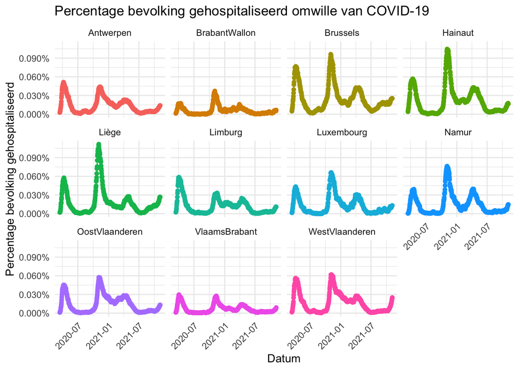

```r
ggplot(data=covid, mapping = aes(x=DATE, y=`Percentage bevolking gehospitaliseerd`, fill=PROVINCE, color=PROVINCE)) +
  geom_point() +
  geom_line() +
  scale_y_continuous(labels=percent) +
  facet_wrap(~PROVINCE) +
  theme_minimal() +
  theme(legend.position="none",
        axis.text.x = element_text(angle = 45, hjust = 1)
        ) +
  labs(x="Datum", title="Percentage bevolking gehospitaliseerd omwille van COVID-19")
```